# GIS Programming: Principles of Programming for GIScientists

# GEO 5934

# Take Attendance!

[figure not shown]

# Why Learn Programming

### What can be done

- Write programs for end users (word processors, games, GIS, etc.)
- Write programs for systems (operating systems, hardware control, etc.)
- Write programs for the internet (websites, web applications)
- ...
- Data science / scientific computing (research)

### The role of computing in science

- Science has traditionally been divided into experimental and theoretical disciplines
- Computing is emerging as an important part of science -> a "third branch"
  - related to theory ("prove it" computationally)
  - related to experiments ("simulate" a world with a known answer)

[figure not shown]

### Openness in Science

- Established code of conduct
  - Theoretical work: publish derivations and proofs
  - Experimental work: publish methods used and results (with detailed experimental data available upon request)
- Computational work does not have established rules
  - Rare to publish source code -> considered a competitive advantage (or unnecessary)
  - Starting to see editorials [[1](https://github.com/sjsrey/ors/blob/master/submitted.md)] [[2](http://www.sciencemag.org/content/334/6060/1226)] and conference sessions [[1](http://meridian.aag.org/callforpapers/program/SessionDetail.cfm?SessionID=20358)] [[2](http://meridian.aag.org/callforpapers/program/SessionDetail.cfm?SessionID=20359)] calling for increased openness
- How to do it?
  - During peer review
  - In perpetuity (software dependencies, hardware needs, etc.)

### Requirements on Scientific Computing

- Replication: ability to rerun the simulations and replicate the results
- Reproducibility: ability to get the same results using an independent implementation of the method or using a different method altogether
- Good for "science" and good for your sanity

### Repetitive Work

- Creates a "paper" trail
- Computers don't get bored
- Computers work 24 hours a day

### Should it be this difficult?

[figure not shown]

Why don't you ride a tricycle anymore?

**Listen to this story in full**. The podcast is broadly about how humans communicate with computers. Although their examples involve hardware inputs, consider the story from the prospective of working in a programming language like Python vs using Excel or ArcGIS. http://99percentinvisible.org/episode/of-mice-and-men/

# Computational Thinking

"Informally we might define CT as a set of thinking or problem-solving strategies that are used to solve problems when working with computers, and that can also be applied to many problem types, even absent the computer."

"Formulating problems in a way that enables us to use a computer and other tools to help solve them."

- **Decomposition**: The ability to break down a task into minute details so that we can clearly explain a process to another person or to a computer, or even to just write notes for ourselves. Decomposing a problem frequently leads to pattern recognition and generalization, and thus the ability to design an algorithm.
- **Pattern Recognition**: The ability to notice similarities or common differences that will help us make predictions or lead us to shortcuts. Pattern recognition is frequently the basis for solving problems and designing algorithms.
- **Pattern Generalization and Abstraction**: The ability to filter out information that is not necessary to solve a certain type of problem and generalize the information that is necessary. Pattern generalization and abstraction allows us to represent an idea or a process in general terms (e.g., variables) so that we can use it to solve other problems that are similar in nature.
- **Algorithm Design**: The ability to develop a step-by-step strategy for solving a problem. Algorithm design is often based on the decomposition of a problem and the identification of patterns that help to solve the problem. In computer science as well as in mathematics, algorithms are often written abstractly, utilizing variables in place of specific numbers.

http://csta.acm.org/Communications/sub/CSTAVoice_Files/csta_voice_05_2011.pdf  
https://www.google.com/edu/computational-thinking/what-is-ct.html

### Simple Daily Examples

- Looking up a name in an alphabetically sorted list
  - Linear: start at the top
  - Binary search: start in the middle
- Standing in line at a bank, supermarket, customs & immigration
  - Performance analysis of task scheduling
- Taking your kids to soccer, gymnastics, and swim practice
  - Traveling salesman (with more constraints)
- Cooking a gourmet meal
  - Parallel processing: You don’t want the meat to get cold while you’re cooking the vegetables.
- Cleaning out your garage
  - Keeping only what you need vs. throwing out stuff when you run out of space.
- Storing away your child’s Lego pieces scattered on the living room floor
  - Using hashing (e.g., by shape, by color)
- Doing laundry, getting food at a buffet
  - Pipelining the wash, dry, and iron stages; plates, salad, entrée, dessert stations

modified from a list by Jeannette M. Wing

# Why Python

[figure not shown]

> Let us change our traditional attitude to the construction of programs: Instead of imagining that our main task is to instruct a computer what to do, let us concentrate rather on explaining to humans what we want the computer to do.

> Donald E. Knuth, Literate Programming, 1984

### What is Python?

- Simple, clean syntax
- Easy to learn (relative to other programming languages)
- Object oriented
- Interpreted: no need to compile code
- Dynamically typed: no need to define the type of variables
- Automatic memory management
- Interactive
- Runs on all major operating systems (Windows, Mac, Linux)
- Open source (free)
- Expressive: do more with fewer lines of code
- Lean: modules

### What can you do with Python?

- OS support: manage files and directories
- Glue existing applications together
- Scientific abstraction
  - access to powerful C and Fortran libraries
  - parallel
- Data Analysis
- Visualization
- Build GUIs
- Scrape websites
- Build websites
- *Anything!*

### Performance

> “The greatest performance improvement comes from going to the working state from the non-working state”

> "CPU time is cheap, my time is expensive"
- Expressive: minimal time required to develop code
- Rapid prototyping
  - Compact (20,000 lines in Python is approximately 100,000 lines in Java or 200,000 lines C)
- Interpreted and dynamically typed means it is slower
  - Is this a problem if the code we write takes a few seconds?
  - Use optimized libraries: e.g. [numpy](https://http://www.numpy.org) , [scipy](https://http://scipy.org)
  - Find the bottleneck and write it in C/C++/Fortran: e.g. [f2py](http://www.scipy.org/F2py), [cython](http://docs.cython.org/)
- Implementing the built-in Python modules would require some advanced programming skills in other languages

### Modules

- A large standard (built-in) library
- A large collection of add-on packages
  - Numerical computing: Numpy, Scipy (BLAS and LAPACK)
  - Visualization: Matplotlib, Seaborn (links to R)
  - Data wrangling: Pandas
  - Parallel Computing: IPython, multiprocessing, mpi4Py
  - Performance: cProfile
  - Mixed Language Programming: C, C++, Fortran
  - Database: SQLite
  - Web: Django
  - GIS and spatial analysis: PySAL, shapely, geopandas, cartopy
  - Optimization: cplex, gurobi

### Popularity: Industry

[figure not shown]

"Most Popular Programming Languages" based on thousands of data points we've collected by processing over 100,000+ coding tests and challenges by over 2,000+ employers."

Source: http://blog.codeeval.com/codeevalblog/2014#.U3weNS_rcqg, http://blog.codeeval.com/codeevalblog/2015#.VctFzbeQy0I=

### Popularity: Current Jobs

[figure not shown]

Source: http://r4stats.com/articles/popularity/

### Popularity: Job Trends

[figure not shown]

Source: http://r4stats.com/articles/popularity/

### Popularity

[figure not shown]

The ratings are based on the number of skilled engineers world-wide, courses and third party vendors. Popular search engines such as Google, Bing, Yahoo!, Wikipedia, Amazon, YouTube and Baidu are used to calculate the ratings.

Source: http://www.tiobe.com/index.php/content/paperinfo/tpci/index.html

### Popularity (long term)

[figure not shown]

The ratings are based on the number of skilled engineers world-wide, courses and third party vendors. Popular search engines such as Google, Bing, Yahoo!, Wikipedia, Amazon, YouTube and Baidu are used to calculate the ratings.

Source: http://www.tiobe.com/index.php/content/paperinfo/tpci/index.html

# Examples (just for fun, not quiz material)

```
0                       POLYGON ((0 0, 1 0, 1 1, 0 0))
1    POLYGON ((2 0.5, 1.997592363336099 0.450991429...
2                  POLYGON ((2 0, 3 0, 3 1, 2 1, 2 0))
dtype: object
```

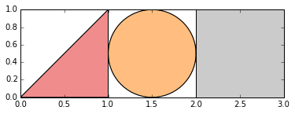

```python
%matplotlib inline
import geopandas as gp
from shapely.geometry import Polygon, Point
poly1 = Polygon([(0, 0), (1, 0), (1, 1)])
poly2 = Polygon([(2, 0), (3, 0), (3, 1), (2, 1)])
circle = Point([(1.5, 0.5)]).buffer(0.5)
g = gp.GeoSeries([poly1, circle, poly2])

print g
g.plot()
```

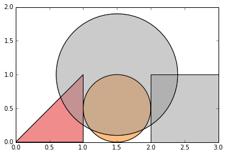

```python
big_circle = Point([1.5, 1.0]).buffer(0.9)
g.plot()
gp.GeoSeries([big_circle]).plot()
```

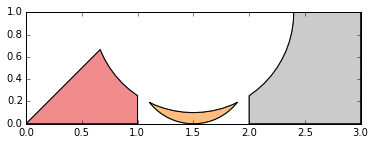

```python
g.difference(big_circle).plot()
```

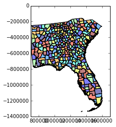

```python
counties = gp.GeoDataFrame.from_file('figures15/fl_neighborhood_counties.shp')
counties.plot()
```

```
Index([     u'ALAND',     u'AWATER',     u'CBSAFP',    u'CLASSFP',
         u'COUNTYFP',   u'COUNTYNS',      u'CSAFP',   u'FUNCSTAT',
            u'GEOID',    u'GISJOIN',   u'INTPTLAT',   u'INTPTLON',
             u'LSAD',   u'METDIVFP',      u'MTFCC',       u'NAME',
         u'NAMELSAD',    u'STATEFP', u'Shape_Area', u'Shape_Leng',
         u'geometry'],
      dtype='object')
[u'13' u'01' u'45' u'12']
```

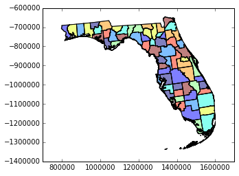

```python
print counties.columns
print counties.STATEFP.unique()
counties[counties.STATEFP=='12'].plot()
```

# This Course

## GIS Programming: Principles of Programming for GIScientists

### Goals

- Learn programming
- Learn python
- Be able to use python to solve geographic, spatial analysis and data analysis problems

Big picture: limits to your research should be in the ideas you can dream up, not the tools that are available.

### Learning Programming

1. Syntax of the language
   - Vocabulary and grammar
   - A bunch of (somewhat isolated) pieces
2. Application to practical problems
   - Communication of a complete idea
   - Putting the pieces together

### Typical Week

1. At home
   - Finish up the in-class exercise (if not already finished during class)
   - Study the new material
     - IPython notebook (interactive coding environment)
     - Supplemented with audio/video of me explaining stuff (sometimes)
     - Supplemented with readings
     - Chatroom to discuss material
2. In class
   - Questions / discussion on the new material
   - Quiz on the new material
   - In-class exercise that applies what you worked on at home

```python
from IPython.display import YouTubeVideo
YouTubeVideo("r2b7GeuqkPc")
```

[video not shown]

### Classroom

We will move to Student Services 219 next week.

### Organization and Grading

1. Python Basics
   - 9 weeks
   - How the language works and how to use it
   - Quizzes (~40% of grade)
   - Participation (~8% of grade)
2. Student Led
   - 4 weeks
   - Python package presentations (~8% of grade)
   - Time to work on individual projects
3. Project
   - Proposal due midway through the semester (~3% of grade)
   - Project presentation at last meeting (~8% of grade)
   - Code and paper due at end of semester (~33% of grade)

### Syllabus

Full syllabus: http://folchcourses.github.io/geo5934_fall2015/

# Tools

### Python Itself

- Free and open source
- Python 2.x vs. 3.x
- Already installed on Mac or Linux
- Not part of Windows
  - Already installed with ArcGIS (kinda)

### Get Python

- Option 1
  - goto python.org, download python and install
  - goto the (unique) website for each package we'll use in the course, download and install
  - don't forget to install all the dependencies (including compiling Fortran and C libraries)
  - once installed get everyone to play nice with each other
- Option 2 (recommended)
  - Enthought Python distribution
  - python and all the packages in one shot
  - easy to install, easy to remove
  - https://www.enthought.com/products/canopy/
  - Step-by-step installation directions: http://folchcourses.github.io/canopy_install.html
  - Anaconda python offers something similar (https://store.continuum.io/cshop/anaconda/)

### Interactive coding

- Write code using a text editor:
  - Mac [Text Wrangler](http://www.barebones.com/products/textwrangler/)
  - Windows [Notepad ++](http://notepad-plus-plus.org/)
  - All [Vim](http://www.vim.org/download.php)
  - All [Sublime Text](http://www.sublimetext.com/)
- Run your code (often) in a **IPython** or **python** terminal
- Fix issues
- Repeat

### GitHub

- Version control system
- Great for collaboration -> different than Dropbox
- All class materials can be found there
- Increasing usage over the semester

### Gitter

- Chat environment for the course
- Apps for phones and computers
- One "room" for each week
- I (strongly) encourage you to ask and answer questions
- If you email me a question I will likely respond on Gitter

### Python Resources

- Official book for this course
  - [Think Python](http://www.greenteapress.com/thinkpython/): free book on Python
  - Hard copy, PDF or HTML
- Other books
  - everything: Learning Python, 5th Edition by Mark Lutz
  - data analysis: [Python for Data Analysis: Data Wrangling with Pandas, NumPy, and IPython](http://www.amazon.com/Python-Data-Analysis-Wrangling-IPython/dp/1449319793) by Wes McKinney
- Online
  - [Python](http://www.python.org/): official Python web site.
  - [Python tutorials](http://docs.python.org/2/tutorial/): official Python tutorials
  - Google
  - Stack Exchange

# Exercise

#### Complete this before next week

- Setup git related accounts and software: http://folchcourses.github.io/new_account.html
- Install Python and related software: http://folchcourses.github.io/canopy_install.html
- Listen to poscast: http://99percentinvisible.org/episode/of-mice-and-men/